# How to use EcoDiet with stomachal and isotopic data

Heloise Thero

2020-01-17

The goal of EcoDiet is to combine biotracers and stomach content analyses together with *a priori* knowledge from the literature to simulataneously identify who eats whom in the food web (**topology matrix**), and in which proportions (**diet matrix**).

More specifically, EcoDiet is an integrated Bayesian model that uses *(i)* stomach content analyses and priors from studies found in the literature to estimate the probability that any trophic link exists *(ii)* biotracers analyses and priors from studies found in the literature to estimate the dietary proportions of each consumer in the food web conditionnally to the trophic links identified.

There are two ways of using this package:

- *Default option* - Only stomach content and biotracers data are integrated, and non informative priors will be used;
- Stomach content and biotracers data are integrated and results from a literature search are used to formulate informative priors.

In this vignette, we present and detail the first and default option.

Note that biotracers data will be here illustrated by bulk stable isotope only, but EcoDiet could be used to treat other analyses such as fatty acids or specific-compounds stable isotopes.

## Load the package

The first thing to do is to load the EcoDiet package.

```r
library(EcoDiet)
```

EcoDiet requires the installation of JAGS (see [the README](https://github.com/heloisethero/EcoDiet/blob/master/README.md) if you have an error).

## Load and check your data

Then, you need to load the data you want to be analyzed by EcoDiet. You can load your data by importing it from `.csv` files. To be treated by the package, your data should be in specific formats, similar to those of following examples.

- Isotopic data:

```r
example_isotope_data_path <- system.file("extdata", "example_isotope_data.csv",
                                    package = "EcoDiet")
example_isotope_data <- read.csv(example_isotope_data_path)
knitr::kable(example_isotope_data)
```

| group | d13C | d15N |
| --- | --- | --- |
| large | -15.95847 | 14.403334 |
| large | -16.15356 | 15.567270 |
| small | -18.79906 | 10.961047 |
| small | -17.10119 | 10.085150 |
| small | -16.65902 | 9.640178 |
| small | -16.98150 | 10.008694 |
| small | -16.16496 | 9.491920 |
| small | -16.41062 | 9.417882 |
| small | -16.24351 | 9.293024 |
| small | -16.90209 | 9.562465 |
| huge | -14.55875 | 16.580950 |
| huge | -15.32830 | 18.026082 |
| huge | -13.82228 | 15.253682 |
| huge | -14.75258 | 18.211747 |
| huge | -14.57365 | 16.503685 |
| huge | -16.19162 | 20.066633 |
| huge | -14.42661 | 17.359560 |
| huge | -15.85425 | 20.044947 |
| huge | -13.79784 | 15.196999 |
| medium | -15.93599 | 13.539739 |
| medium | -15.26630 | 12.716846 |
| medium | -15.65510 | 14.201679 |
| medium | -15.99874 | 13.664872 |
| medium | -16.00935 | 14.090937 |

Each line of the table represents one individual on which were conducted stable isotope analyses. For a given individual, stable isotope analyses can be realized for various elements (carbon and nitrogen in this example). The first column of the table indicates to which trophic group the individual belongs and the others contain the isotopic measurements.

- Stomachal data:

```r
example_stomach_data_path <- system.file("extdata", "example_stomach_data.csv",
                                    package = "EcoDiet")
example_stomach_data <- read.csv(example_stomach_data_path)
knitr::kable(example_stomach_data)
```

| X | small | medium | huge | large |
| --- | --- | --- | --- | --- |
| large | 0 | 0 | 17 | 0 |
| huge | 0 | 0 | 0 | 0 |
| small | 0 | 12 | 0 | 22 |
| medium | 0 | 0 | 12 | 4 |
| full | 0 | 12 | 19 | 24 |

The stomach content table gathers the sum of occurrences of each prey type in the stomachs of trophic groups. The first column of the table contains the names of the prey and the headers of the following columns contain the names of **all** trophic groups with or without stomach content analyses available: in the case where no analyses were available, as for groups at the base of the trophic network, a column filled with zeros must be provided.

The last row of the table indicates how many (non-empty) stomachs have been analyzed for each trophic group.

In this example, for the “huge” animals, 19 stomachs were analyzed and contained remainings. Among these stomachs, 17 contain “Large” animal remainings and 12 contain “medium” animal remainings.

## Plot the data

You can visualize your data with the `plot_data` function:

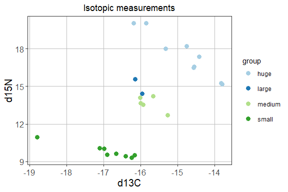

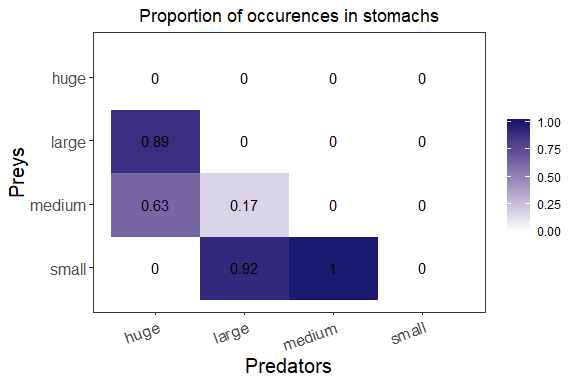

```r
plot_data(isotope_data = example_isotope_data,
          stomach_data = example_stomach_data)
```

## Preprocess the data

- You first need to have loaded your `.csv` files as shown previously.

If you have your files in a `data` folder and in a specific `.csv` format (semicolon separated, and not coma separated), you should add the `data` folder in the path and use the `sep` argument to load your data:

```r
example_stomach_data <- read.csv("./data/my_stomach_data.csv",     sep = ";")
example_isotope_data <- read.csv("./data/my_isotope_data.csv",     sep = ";")
```

- You need to define the trophic enrichment factors that corresponds to your isotopic data. If your isotopic data files contains d13C and d15N data as in the example, then you should enter the trophic enrichment factors for the d13C and d15N isotopes (in that order):

```r
trophic_enrichment_factor = c(0.8, 3.4)
```

- You also need to precise that you won’t use priors from the literature in the model:

```r
literature_prior = FALSE
```

- The `preprocess_data` function then checks and rearranges the data in a specific format so that the EcoDiet model can be run:

```r
data <- preprocess_data(isotope_data = example_isotope_data,
                        trophic_enrichment_factor = c(0.8, 3.4),
                        literature_prior = FALSE,
                        stomach_data = example_stomach_data)
```

```
#> The model will investigate the following trophic links:
#>        huge large medium small
#> huge      0     0      0     0
#> large     1     0      0     0
#> medium    1     1      0     0
#> small     0     1      1     0
#> If you want to add other links, you can define a new matrix with the `trophic_links` argument.
```

If any error appears, it means your data is not in the correct format. Please read the error message and try to rearrange the data in the correct format.

## Check the trophic links matrix

The last message tells you to check the trophic links that will be investigated by the model. It is generally not wise to assume that all the trophic links are possible ( = a matrix filled with only ones), as the model will likely be over-paramaterized and have problems to converge. You therefore need to keep only the reasonnable trophic links (e.g., a shrimp cannot eat a whale).

The matrix displayed by the `preprocess_data` function is based on the stomach content data: by-default, EcoDiet will investigate trophic links only based on what you have found in stomachs analyses. If you want to add another trophic link, you can modify directly the topological matrix. The by-default topological matrix can be defined by the following instruction :

```r
trophic_links <- 1 * (data$o > 0)
print(trophic_links)
```

```
#>        huge large medium small
#> huge      0     0      0     0
#> large     1     0      0     0
#> medium    1     1      0     0
#> small     0     1      1     0
```

Additional trophic links (= trophic links that do not appear in the stomach content data but that you know to exist in the trophic network) can be added by hand. For example, to specify that the “huge” animal can also eat “small” animals (even if none was found in the huge’s stomachs), you can do:

```r
trophic_links["small", "huge"] <- 1
print(trophic_links)
```

```
#>        huge large medium small
#> huge      0     0      0     0
#> large     1     0      0     0
#> medium    1     1      0     0
#> small     1     1      1     0
```

Now the new topological matrix can be entered as an argument of the `preprocess_data` function, and you can see that the new trophic links matrix will be investigated by the model:

```r
data <- preprocess_data(isotope_data = example_isotope_data,
                        trophic_enrichment_factor = c(0.8, 3.4),
                        literature_prior = FALSE,
                        trophic_links = trophic_links,
                        stomach_data = example_stomach_data)
```

```
#> The model will investigate the following trophic links:
#>        huge large medium small
#> huge      0     0      0     0
#> large     1     0      0     0
#> medium    1     1      0     0
#> small     1     1      1     0
#> If you want to add other links, you can define a new matrix with the `trophic_links` argument.
```

## Write the model

The `write_model` function writes the model in the BUGS syntax. The option non informative priors / informative priors must be specified again at this level.

```r
model_string <- write_model(literature_prior = FALSE)
```

## Run the model

Now that the model is defined, you can use the function `run_model` to run the model. By default the number of MCMC iterations is very low (1,000), it allows you to test if your model is compiling properly. In most of the cases, this low number of iterations is not sufficient to achieve a satisfactory model convergence (as you can see from the warning message):

```r
mcmc_output <- run_model(textConnection(model_string), data)
```

```
#>
#>
#>
#> Burning in the MCMC chains...
#>
#>
#> Sampling finally the MCMC chains...
#> The model took 3.5 secs to run.
#> Warning message:
#>   Convergence problem
#> Out of the 12 variables, 2 variables have a Gelman-Rubin statistic > 1.1.
#> You should increase the number of iterations of your model with the `nb_iter` argument.
```

We advise you to increase the number of iterations until you have met the convergence threshold:

```r
mcmc_output <- run_model(textConnection(model_string), data, nb_iter = 1e+06)
```

If you see again a warning message being printed, you should follow the advices of the corresponding vignette: `vignette("model_warnings")`.

## Plot and save the model’s mean results

In Bayesian models, the parameters are represented by their probability distributions. So here the model’s outputs are the approximated probability distributions for the diet propotions (PI) and the trophic links probabilities (eta). To summarize these distributions, we can use point estimates like the mean and visualize it with the `plot_results` function:

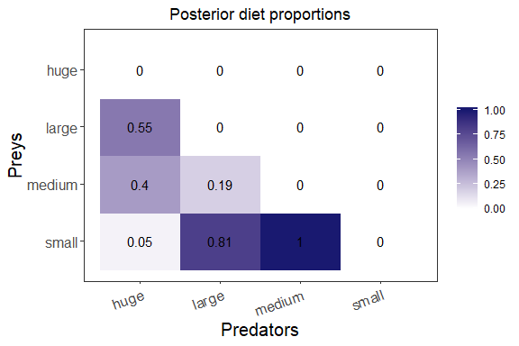

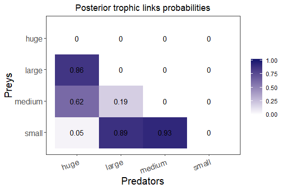

```r
plot_results(mcmc_output, data)
```

The means are automatically saved when running this function so you can access them and save them as `.csv` tables:

```r
load("PI_mean.Rdata")
write.table(PI_mean,  file = "PI_mean.csv",  sep = ",", col.names = NA)

load("eta_mean.Rdata")
write.table(eta_mean, file = "eta_mean.csv", sep = ",", col.names = NA)
```

## Plot the probability densities

You can also plot the probability densities for the `PI` variable and for one predator:

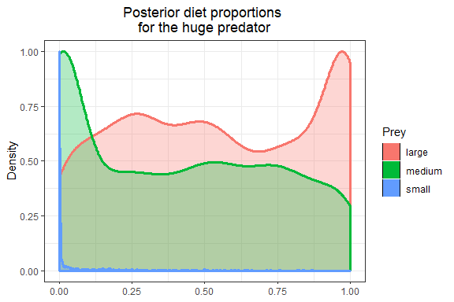

```r
plot_results(mcmc_output, data, variables = "PI", pred = "huge")
```

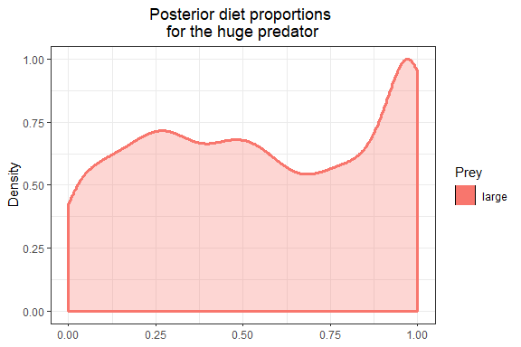

```r
plot_results(mcmc_output, data, variables = "PI", pred = "huge", prey = "large")
```

## Save the full results

The model’s full results are automatically saved in a file named `mcmc_ouput` so you can access them using:

```r
load("mcmc_output.Rdata")
mcmc_output <- signif(mcmc_output, digits = 2)
knitr::kable(head(mcmc_output))
```

| PI[2,1] | PI[3,1] | PI[4,1] | PI[3,2] | PI[4,2] | PI[4,3] | eta[2,1] | eta[3,1] | eta[4,1] | eta[3,2] | eta[4,2] | eta[4,3] |
| --- | --- | --- | --- | --- | --- | --- | --- | --- | --- | --- | --- |
| 0.110 | 0.89 | 2.3e-05 | 0.079 | 0.92 | 1 | 0.89 | 0.65 | 0.0096 | 0.200 | 0.85 | 0.84 |
| 0.240 | 0.76 | 1.5e-05 | 0.250 | 0.75 | 1 | 0.74 | 0.66 | 0.0120 | 0.240 | 0.92 | 0.94 |
| 0.130 | 0.87 | 1.3e-04 | 0.250 | 0.75 | 1 | 0.82 | 0.80 | 0.0054 | 0.077 | 0.85 | 0.98 |
| 0.052 | 0.95 | 2.3e-05 | 0.150 | 0.85 | 1 | 0.87 | 0.48 | 0.0990 | 0.220 | 0.86 | 1.00 |
| 0.029 | 0.97 | 2.9e-05 | 0.010 | 0.99 | 1 | 0.97 | 0.55 | 0.0080 | 0.090 | 0.84 | 0.70 |
| 0.180 | 0.82 | 1.0e-04 | 0.021 | 0.98 | 1 | 0.82 | 0.71 | 0.0120 | 0.180 | 0.86 | 0.95 |

You can now compute any summary statistics that you need, on top of the mean. For example if you want the median (thus the 50% quantile), and the 5% and the 95% quantiles of your distribution, you can use:

```r
quantiles <- apply(mcmc_output, 2, function(X) quantile(X, probs = c(0.05, 0.5, 0.95)))
quantiles <- signif(quantiles, digits = 2)
knitr::kable(quantiles)
```

|  | PI[2,1] | PI[3,1] | PI[4,1] | PI[3,2] | PI[4,2] | PI[4,3] | eta[2,1] | eta[3,1] | eta[4,1] | eta[3,2] | eta[4,2] | eta[4,3] |
| --- | --- | --- | --- | --- | --- | --- | --- | --- | --- | --- | --- | --- |
| 5% | 0.024 | 1.0e-06 | 0.0e+00 | 0.000 | 0.28 | 1 | 0.74 | 0.44 | 0.0024 | 0.08 | 0.77 | 0.79 |
| 50% | 0.540 | 3.8e-01 | 4.8e-05 | 0.036 | 0.96 | 1 | 0.87 | 0.62 | 0.0330 | 0.18 | 0.90 | 0.95 |
| 95% | 1.000 | 9.7e-01 | 3.0e-01 | 0.720 | 1.00 | 1 | 0.96 | 0.78 | 0.1400 | 0.32 | 0.97 | 1.00 |

The quantiles can finally be saved as `.csv` tables:

```r
write.table(quantiles, file = "quantiles.csv", sep = ",", col.names = NA)
```

## Plot the prior distributions

You can also plot the prior distributions by running the model with empty data. To do so, you can use the following instructions:

```r
data$o[] <- NA
data$y[] <- NA
data$nb_y[] <- 0

mcmc_priors <- run_model(textConnection(model_string), data,
                         nb_adapt = 1e2, nb_burnin = 1, nb_iter = 1e5)
```

```
#>
#>
#>
#> Burning in the MCMC chains...
#>
#>
#> Sampling finally the MCMC chains...
#> The model took 22.4 secs to run.
```

You can now plot the prior distributions you are interested in:

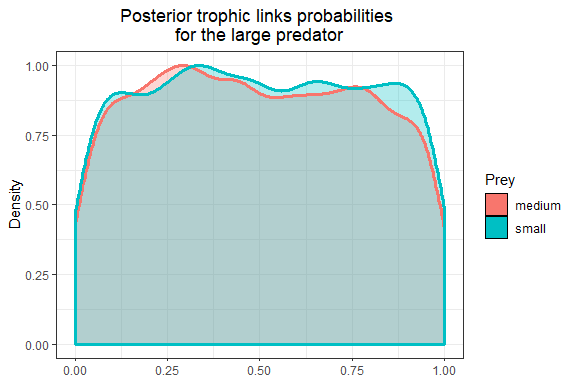

```r
plot_results(mcmc_priors, data, variables = "eta", pred = "large")
```

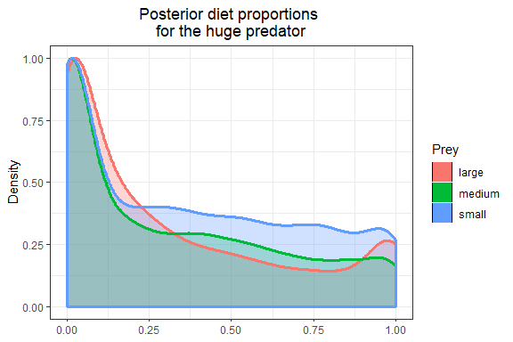

```r
plot_results(mcmc_priors, data, variables = "PI", pred = "huge")
```

## Save another variable than PI and eta

You have the possibility to access to the model’s other parameters if you wish.

For example you may be interested by the variable `delta` that represents the trophic enrichment factor. In the EcoDiet model, a different trophic enrichment factor is used for each trophic group and for each element, allowing some differences between species. We can save these parameters using the `variables_to_save` argument:

```r
mcmc_output <- run_model(textConnection(model_string), data,
                         variables_to_save = c("delta"))
```

```
#>
#>
#>
#> Burning in the MCMC chains...
#>
#>
#> Sampling finally the MCMC chains...
#> The model took 0.7 secs to run.
#> Warning message:
#>   Convergence problem
#> Out of the 6 variables, 6 variables have a Gelman-Rubin statistic > 1.1.
#> You should increase the number of iterations of your model with the `nb_iter` argument.
```

And now you can access its mean value using:

```r
print(colMeans(mcmc_output))
```

```
#> delta[1,1] delta[2,1] delta[1,2] delta[2,2] delta[1,3] delta[2,3]
#>  -0.636385  -7.755568   2.885247   3.922306   1.864482  -3.377711
```